**Introduction**  
This report seeks to build a model to predict the activity (output variable “classe”) that was performed from a list of inputs collected from on-body sensors. The inputs were collected from a group of six participants aged between 20 to 28, carrying out ten (10) repetitions of dumbbell curl for each of the five different variations identified by “classe”.

Output variable: classe  
- Categorical variable consisting of five (5) levels  
A: According to specification  
B: Throwing the elbows to the front  
C: Lifting the dumbbell only halfway  
D: Lowering the dumbbell only  
E: Throwing the hips to the front

**Selection of features**  
Relevant variables with descriptions of *roll, pitch, yaw, gyros, accel* and *magnet* are used as they are the information collected from the four *[Ref 3]* sensors.

Within these variables, those that contains *“NA”* or *“#DIV/0!”* are removed from the model as they offer no useful information for model building.

In addition, variables such as time stamps, windows or names of participants are removed as the model will be more useful for prediction of classe action from sensor information that is independent of time of the action performed and independent of the participants.

```r
## Tidy dataset to select relevant information & features
classe<-training[,grep("^classe",names(training))]
roll<-training[,grep("^roll",names(training))]
pitch<-training[,grep("^pitch",names(training))]
yaw<-training[,grep("^yaw",names(training))]
gyros<-training[,grep("^gyros",names(training))]
acc<-training[,grep("^accel",names(training))]
magnet<-training[,grep("^magnet",names(training))]
training<-data.frame(classe,roll,pitch,yaw,gyros,acc,magnet)
```

**Model Building**  
The simplified training data set (non relevant variables removed) partitioned with 70% used for training and 30% for testing.

```r
## Create partition
inTrain<-createDataPartition(training$classe,p = 0.7, list=FALSE)
m_train<-training[inTrain,]
m_test<-training[-inTrain,]
```

Following the strategy of Dr Max [Ref 2, Pg 25], a powerful model is selected to determine the initial performance and then followed by fitting the simplest possible model. As such, random forest is used to determine the model.

```r
## Use random forest to create model with automatic rerun using the 10 important
## variables, mdim2nd =10

rfFit<-randomForest(classe~.,data=m_train, imp=1, mdim2nd=10, impout=1)

rfFit ## call out model
```

```
##
## Call:
##  randomForest(formula = classe ~ ., data = m_train, imp = 1, mdim2nd = 10,      impout = 1)
##                Type of random forest: classification
##                      Number of trees: 500
## No. of variables tried at each split: 6
##
##         OOB estimate of  error rate: 0.51%
## Confusion matrix:
##      A    B    C    D    E class.error
## A 3902    4    0    0    0    0.001024
## B    9 2646    3    0    0    0.004515
## C    0   15 2378    3    0    0.007513
## D    0    0   25 2225    2    0.011989
## E    0    0    3    6 2516    0.003564
```

```r
## Test model against test samples using random forest model
confusionMatrix(m_test$classe,predict(rfFit,m_test))
```

```
## Confusion Matrix and Statistics
##
##           Reference
## Prediction    A    B    C    D    E
##          A 1674    0    0    0    0
##          B    5 1134    0    0    0
##          C    0    3 1020    3    0
##          D    0    0    7  956    1
##          E    0    0    0    2 1080
##
## Overall Statistics
##
##                Accuracy : 0.996
##                  95% CI : (0.995, 0.998)
##     No Information Rate : 0.285
##     P-Value [Acc > NIR] : <2e-16
##
##                   Kappa : 0.995
##  Mcnemar's Test P-Value : NA
##
## Statistics by Class:
##
##                      Class: A Class: B Class: C Class: D Class: E
## Sensitivity             0.997    0.997    0.993    0.995    0.999
## Specificity             1.000    0.999    0.999    0.998    1.000
## Pos Pred Value          1.000    0.996    0.994    0.992    0.998
## Neg Pred Value          0.999    0.999    0.999    0.999    1.000
## Prevalence              0.285    0.193    0.175    0.163    0.184
## Detection Rate          0.284    0.193    0.173    0.162    0.184
## Detection Prevalence    0.284    0.194    0.174    0.164    0.184
## Balanced Accuracy       0.999    0.998    0.996    0.997    0.999
```

As per reference [4], there is no need for cross-validation or a separate test set to get an unbiased estimate of the test set error.

```r
## Use random forest to create model with automatic rerun using the 4 important
## variables, mdim2nd =4
rfFit3<-randomForest(classe~.,data=m_train, imp=1, mdim2nd=4, impout=1)

rfFit3 ## call out model with 4 important variables
```

```
##
## Call:
##  randomForest(formula = classe ~ ., data = m_train, imp = 1, mdim2nd = 4,      impout = 1)
##                Type of random forest: classification
##                      Number of trees: 500
## No. of variables tried at each split: 6
##
##         OOB estimate of  error rate: 0.5%
## Confusion matrix:
##      A    B    C    D    E class.error
## A 3899    5    1    1    0    0.001792
## B    9 2644    5    0    0    0.005267
## C    0   12 2383    1    0    0.005426
## D    0    0   26 2224    2    0.012433
## E    0    0    1    5 2519    0.002376
```

```r
## Test model against test samples using random forest model
confusionMatrix(m_test$classe,predict(rfFit3,m_test))
```

```
## Confusion Matrix and Statistics
##
##           Reference
## Prediction    A    B    C    D    E
##          A 1673    0    0    0    1
##          B    5 1134    0    0    0
##          C    0    3 1020    3    0
##          D    0    0   10  953    1
##          E    0    0    0    2 1080
##
## Overall Statistics
##
##                Accuracy : 0.996
##                  95% CI : (0.994, 0.997)
##     No Information Rate : 0.285
##     P-Value [Acc > NIR] : <2e-16
##
##                   Kappa : 0.995
##  Mcnemar's Test P-Value : NA
##
## Statistics by Class:
##
##                      Class: A Class: B Class: C Class: D Class: E
## Sensitivity             0.997    0.997    0.990    0.995    0.998
## Specificity             1.000    0.999    0.999    0.998    1.000
## Pos Pred Value          0.999    0.996    0.994    0.989    0.998
## Neg Pred Value          0.999    0.999    0.998    0.999    1.000
## Prevalence              0.285    0.193    0.175    0.163    0.184
## Detection Rate          0.284    0.193    0.173    0.162    0.184
## Detection Prevalence    0.284    0.194    0.174    0.164    0.184
## Balanced Accuracy       0.998    0.998    0.995    0.996    0.999
```

**Prediction using model**

```r
## Print out the results
predict(rfFit,testSet)
```

```
##  1  2  3  4  5  6  7  8  9 10 11 12 13 14 15 16 17 18 19 20
##  B  A  B  A  A  E  D  B  A  A  B  C  B  A  E  E  A  B  B  B
## Levels: A B C D E
```

```r
predict(rfFit3,testSet)
```

```
##  1  2  3  4  5  6  7  8  9 10 11 12 13 14 15 16 17 18 19 20
##  B  A  B  A  A  E  D  B  A  A  B  C  B  A  E  E  A  B  B  B
## Levels: A B C D E
```

**References**  
1) Dataset is obtained from the following website  
http://groupware.les.inf.puc-rio.br/har#ixzz3PB9kU6tp

2. Predictive Modeling with R and the Caret Package by Max Kuhn, Ph.D  
   http://www.jstatsoft.org/v28/i05/
3. Ugulino, W.; Cardador, D.; Vega, K.; Velloso, E.; Milidiu, R.; Fuks, H. Wearable Computing: Accelerometers’ Data Classification of Body Postures and Movements. Proceedings of 21st Brazilian Symposium on Artificial Intelligence. Advances in Artificial Intelligence - SBIA 2012. In: Lecture Notes in Computer Science. , pp. 52-61. Curitiba, PR: Springer Berlin / Heidelberg, 2012. ISBN 978-3-642-34458-9. DOI: 10.1007/978-3-642-34459-6_6. Cited by 2 (Google Scholar)
4. Random Forests by Leo Breiman and Adele Cutler  
   http://www.stat.berkeley.edu/~breiman/RandomForests/cc_home.htm#workings

**Figure 1 showing the importance of variables**

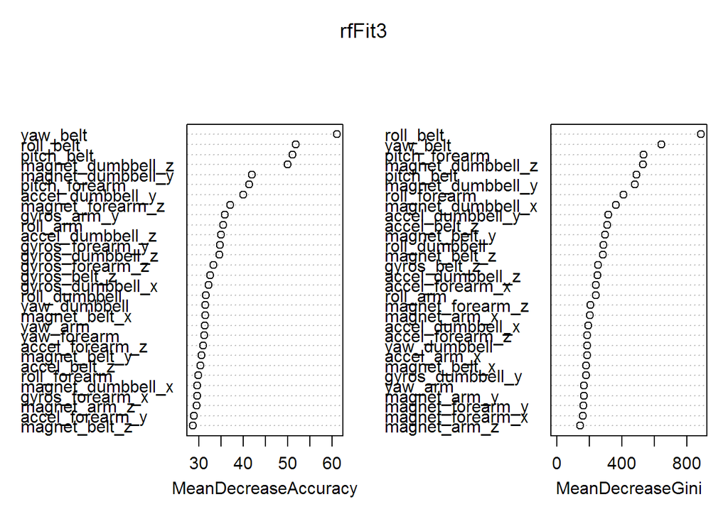